# Psych 254 W15 PS #1

Rhia Catapano

January 21, 2015

This is problem set #1, practicing the packages tidyr and dplyr.

## Preliminaries

We begin by clearing the working directory and loading in a set of useful packages.

```r
rm(list=ls())
source("helper/useful.R")
library("knitr")
```

## Part 1: Data cleaning

Load in data

```r
dat <- read.csv("data/janiszewski_rep_exercise.csv")
dat_original <- dat
```

Check for duplicates

```r
dat[duplicated(dat),]
```

```
##  [1] HITId                       HITTypeId
##  [3] Title                       Description
##  [5] Keywords                    Reward
##  [7] CreationTime                MaxAssignments
##  [9] RequesterAnnotation         AssignmentDurationInSeconds
## [11] AutoApprovalDelayInSeconds  Expiration
## [13] NumberOfSimilarHITs         LifetimeInSeconds
## [15] AssignmentId                WorkerId
## [17] AssignmentStatus            AcceptTime
## [19] SubmitTime                  AutoApprovalTime
## [21] ApprovalTime                RejectionTime
## [23] RequesterFeedback           WorkTimeInSeconds
## [25] LifetimeApprovalRate        Last30DaysApprovalRate
## [27] Last7DaysApprovalRate       Input.condition
## [29] Input.price1                Input.price2
## [31] Input.price3                Answer.dog_cost
## [33] Answer.plasma_cost          Answer.sushi_cost
## <0 rows> (or 0-length row.names)
```

```r
#there are no rows that are completely duplicated

duplicates <- dat[duplicated(dat$WorkerId),]
duplicates
```

```
##                             HITId                      HITTypeId
## 48 2WQ06UFBNFSVWCUUFZWS36NG1CAH35 2DVGTP9RA7S5C4ALLOJOM70JMHCRW9
## 58 2WQ06UFBNFSVWCUUFZWS36NG1CAH35 2DVGTP9RA7S5C4ALLOJOM70JMHCRW9
## 62 2XNTYMNCWYB4PXI74I8X81JONPBLPS 2DVGTP9RA7S5C4ALLOJOM70JMHCRW9
##                                           Title
## 48 How much is it worth? Quick 2 minute survey.
## 58 How much is it worth? Quick 2 minute survey.
## 62 How much is it worth? Quick 2 minute survey.
##                                                              Description
## 48 A quick two minute survey asking about prices. DO THIS HIT ONLY ONCE.
## 58 A quick two minute survey asking about prices. DO THIS HIT ONLY ONCE.
## 62 A quick two minute survey asking about prices. DO THIS HIT ONLY ONCE.
##                 Keywords Reward                 CreationTime
## 48 survey, quick, prices    0.1 Wed Jan 25 18:13:24 GMT 2012
## 58 survey, quick, prices    0.1 Wed Jan 25 18:13:24 GMT 2012
```

[output cut: 37 more lines]

```r
#however, there are duplicate IDs (48,58, 62)

#so, we want the data frame with all of the duplicates removed
dat <- dat[!duplicated(dat$WorkerId),]
```

Check structure/data types

```r
str(dat)
```

```
## 'data.frame':    87 obs. of  34 variables:
##  $ HITId                      : Factor w/ 3 levels "261WKUDD8XMBJ8COBQ261TO6T1XNCJ",..: 1 1 1 1 1 1 1 1 1 1 ...
##  $ HITTypeId                  : Factor w/ 1 level "2DVGTP9RA7S5C4ALLOJOM70JMHCRW9": 1 1 1 1 1 1 1 1 1 1 ...
##  $ Title                      : Factor w/ 1 level "How much is it worth? Quick 2 minute survey.": 1 1 1 1 1 1 1 1 1 1 ...
##  $ Description                : Factor w/ 1 level "A quick two minute survey asking about prices. DO THIS HIT ONLY ONCE.": 1 1 1 1 1 1 1 1 1 1 ...
##  $ Keywords                   : Factor w/ 1 level "survey, quick, prices": 1 1 1 1 1 1 1 1 1 1 ...
##  $ Reward                     : num  0.1 0.1 0.1 0.1 0.1 0.1 0.1 0.1 0.1 0.1 ...
##  $ CreationTime               : Factor w/ 1 level "Wed Jan 25 18:13:24 GMT 2012": 1 1 1 1 1 1 1 1 1 1 ...
##  $ MaxAssignments             : int  30 30 30 30 30 30 30 30 30 30 ...
##  $ RequesterAnnotation        : Factor w/ 1 level "Department:Other": 1 1 1 1 1 1 1 1 1 1 ...
##  $ AssignmentDurationInSeconds: int  600 600 600 600 600 600 600 600 600 600 ...
##  $ AutoApprovalDelayInSeconds : int  604800 604800 604800 604800 604800 604800 604800 604800 604800 604800 ...
##  $ Expiration                 : Factor w/ 1 level "Wed Feb 01 18:13:24 GMT 2012": 1 1 1 1 1 1 1 1 1 1 ...
##  $ NumberOfSimilarHITs        : int  2 2 2 2 2 2 2 2 2 2 ...
##  $ LifetimeInSeconds          : logi  NA NA NA NA NA NA ...
```

[output cut: 20 more lines]

```r
#it looks like the 3 problematic columns are dog_cost, plasma_cost, and sushi_cost. These three should be numeric, but instead are factors.
```

Make incorrectly factored variables into numeric

```r
#Clean up the answers in dog_cost
dat[which(dat$Answer.dog_cost == "five hundred"),]$Answer.dog_cost <- 500
dat[which(dat$Answer.dog_cost == "2,000"), ]$Answer.dog_cost <- 2000
dat[which(dat$Answer.dog_cost == "2499.99"), ]$Answer.dog_cost <- round(as.numeric(as.character(dat[which(dat$Answer.dog_cost == "2499.99"), ]$Answer.dog_cost)))
dat$Answer.dog_cost <- as.numeric(as.character(dat$Answer.dog_cost))

#Clean up the answers in plasma_cost
dat[which(dat$Answer.plasma_cost == "4999.99"), ]$Answer.plasma_cost <- round(as.numeric(as.character(dat[which(dat$Answer.plasma_cost == "4999.99"), ]$Answer.plasma_cost)))
dat[which(dat$Answer.plasma_cost == "0.45"), ]$Answer.plasma_cost <- 4500
#in my own data sets I'd probably exclude this person instead of assuming what they meant, but based on the cleaned version, it seems like we're assuming that they meant 4500.
dat[which(dat$Answer.plasma_cost == "4,000"), ]$Answer.plasma_cost <- 4000
dat$Answer.plasma_cost <- as.numeric(as.character(dat$Answer.plasma_cost))

#Clean up answers in sushi_cost
dat[which(dat$Answer.sushi_cost == "ehight"), ]$Answer.sushi_cost <- 8
dat[which(dat$Answer.sushi_cost == "7,75"), ]$Answer.sushi_cost <- 7.75
dat$Answer.sushi_cost <- as.numeric(as.character(dat$Answer.sushi_cost))

write.csv(dat, "janiszewski_rep_cleaned_Rhia.csv")
```

## Part 2: Making these data tidy

Load in the data

```r
dat2 <- read.csv("data/janiszewski_rep_cleaned.csv")
```

Remove columns we don’t need and rename variables

```r
d.tidy <- dat2 %>%
  select(WorkerId, Input.condition,
         starts_with("Answer")) %>%
  rename(workerid = WorkerId,
         condition = Input.condition,
         dog_cost = Answer.dog_cost,
         plasma_cost = Answer.plasma_cost,
         sushi_cost = Answer.sushi_cost)
```

Gather the data into a tidy data frame

```r
d.gathered <- d.tidy %>%
  gather(type, cost, dog_cost, plasma_cost, sushi_cost)
```

Spread into a wide format

```r
d.wide <- d.gathered %>%
  spread(type, cost)
```

## Part 3: Manipulating the data using dplyr

Histogram representing the number of people in each price range for each item.

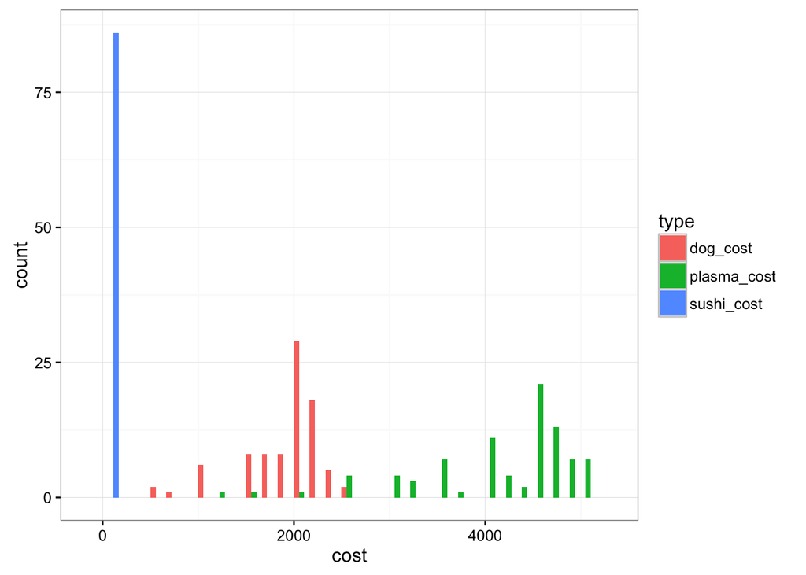

```r
ggplot(d.gathered, aes(x=cost, fill=type)) +
    geom_histogram(position="dodge")
```

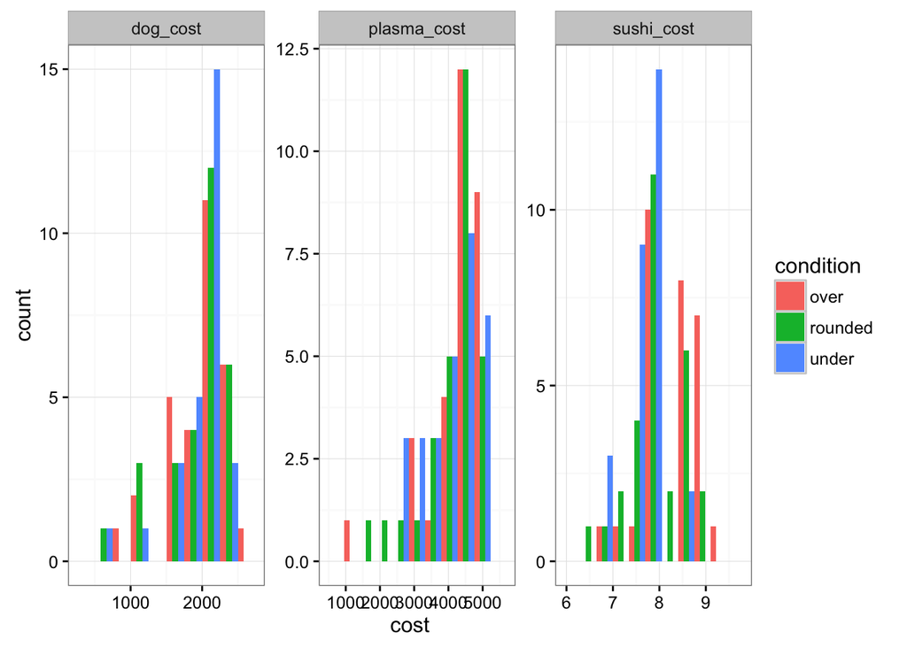

```r
#Histogram
ggplot(data=d.gathered, aes(x=cost, fill=condition)) + facet_wrap(~type, scale="free") + geom_histogram(position="dodge", bins=8)
```

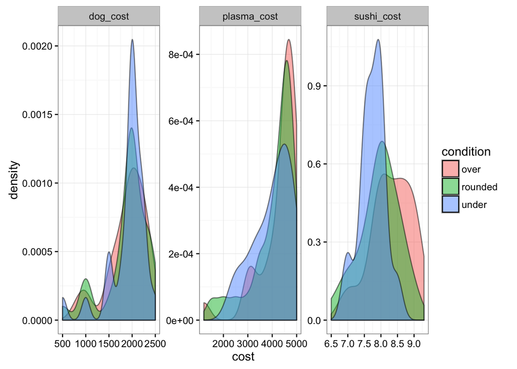

```r
#Density Distribution
ggplot(data=d.gathered, aes(x=cost, fill=condition)) + facet_wrap(~type, scale="free") + geom_density(alpha=0.5)
```

Based on our histogram, we can see that all participants gave a low WTP for sushi, a mid-range WTP for dog, and a high WTP for a plasma TV.

Remove duplicates using distinct from dplyr.

```r
d.raw <- read.csv("data/janiszewski_rep_exercise.csv")
d.unique.subs <- distinct(d.raw, WorkerId)
```

Start by using *summarise* to compute the grand mean bet.

```r
summarise(d.gathered, "mean cost" = mean(cost, na.rm=TRUE))
```

```
##   mean cost
## 1  2022.557
```

Summary by item and condition

```r
summary <- d.gathered %>%
  group_by(type, condition) %>%
  summarise("mean cost" = mean(cost, na.rm=TRUE))

kable(summary)
```

| type | condition | mean cost |
| --- | --- | --- |
| dog_cost | over | 1898.300000 |
| dog_cost | rounded | 1884.482414 |
| dog_cost | under | 1906.964286 |
| plasma_cost | over | 4300.333000 |
| plasma_cost | rounded | 4091.655172 |
| plasma_cost | under | 4018.357143 |
| sushi_cost | over | 8.322414 |
| sushi_cost | rounded | 7.955517 |
| sushi_cost | under | 7.742500 |

We need the anchors, so create a new tidy version of the data set including the anchors.

```r
d.tidy <- dat2 %>%
  select(WorkerId, Input.condition,
         starts_with("Answer"),
         starts_with("Input")) %>%
  rename(workerid = WorkerId,
         condition = Input.condition,
         plasma_anchor = Input.price1,
         dog_anchor = Input.price2,
         sushi_anchor = Input.price3,
         dog_cost = Answer.dog_cost,
         plasma_cost = Answer.plasma_cost,
         sushi_cost = Answer.sushi_cost) %>%
  gather(name, cost,
         dog_anchor, plasma_anchor, sushi_anchor,
         dog_cost, plasma_cost, sushi_cost) %>%
  separate(name, c("item", "type"), "_") %>%
  spread(type, cost)
```

Compute absolute percentage change in price, and * By computing z-scores over items.

To do the first, use the *mutate* verb to add a percent change column, then comute the same summary as before.

```r
pcts <- d.tidy %>%
  mutate(pct_change = (anchor-cost)/anchor*100) %>%
  group_by(item, condition) %>%
  summarise("percentchange" = mean(pct_change, na.rm=TRUE))

kable(pcts)
```

| item | condition | percentchange |
| --- | --- | --- |
| dog | over | 24.31021 |
| dog | rounded | 24.62070 |
| dog | under | 23.47655 |
| plasma | over | 14.19926 |
| plasma | rounded | 18.16690 |
| plasma | under | 19.43951 |
| sushi | over | 11.08532 |
| sushi | rounded | 11.60536 |
| sushi | under | 10.38773 |

Computing z-scores over items

```r
z.scores <- d.tidy %>%
 mutate(change = anchor - cost) %>%
 group_by(item) %>%
 mutate(scaled = scale(change)[,1]) %>%
 ungroup()  %>%
 group_by(item, condition, add=FALSE) %>%
 summarize("groupmeans"=mean(scaled,na.rm=TRUE) )
```

Plot the differences and see if anything happened.

First the percent change:

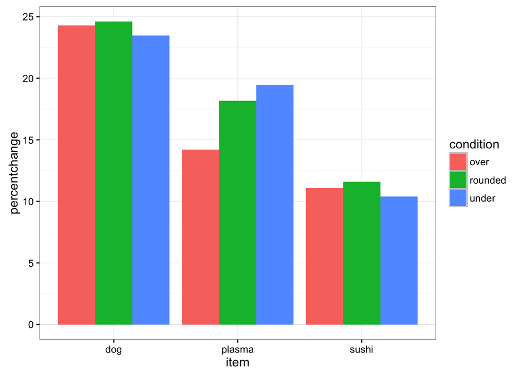

```r
#qplot was removed in the most recent version of ggplot
#qplot(item, percentchange, fill=condition,
 #     position="dodge",
  #    stat="identity", geom="bar",
   #   data=pcts)

ggplot(data=pcts, aes(x=item, y=percentchange, fill=condition)) + geom_bar(stat="identity", position="dodge")
```

and the z-scores:

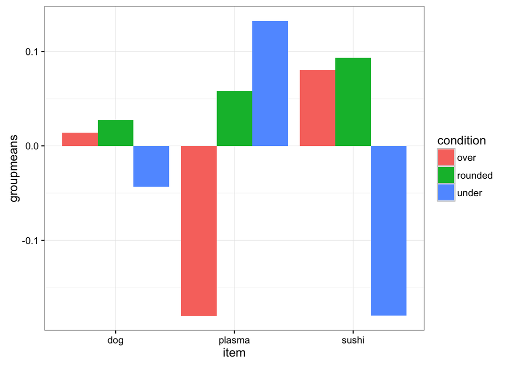

```r
#qplot(item, groupmeans, fill=condition,
 #     position="dodge",
  #    stat="identity", geom="bar",
   #   data=z.scores)

ggplot(data=z.scores, aes(x=item, y=groupmeans, fill=condition)) + geom_bar(stat="identity", position="dodge")
```

This replication didn’t seem to work out straightforwardly.